# The report of exploratory analysis and the goals for the app and algorithm

HU TANG

2022-10-04

## Instruction

This report will highlight the selected data sets, and the exploratory data analysis performed on the three data sets provided by the project. In this report, the three data sets will be converted to corpus’s and then to Ngrams of varying sized.

## The Summary of The raw materials

The comparison of the three files on the number of lines and words is summarized as :

```
##   file_name file_size number_lines number_words
## 1   twitter    319 Mb      2360148     30451128
## 2      news  257.3 Mb      1010242     34494539
## 3     blogs  255.4 Mb       899288     37570839
```

The table above indicate that the file size of twitter is largest, which is 319Mb.

## The Summary of the subsetted Files

```
##     file_name file_size number_lines number_words
## 1 sub_twitter    3.2 Mb        23601       303075
## 2    sub_news    2.6 Mb        10102       343842
## 3   sub_blogs    2.6 Mb         8992       375584
```

## Create corpus and review a word cloud from full corpus with upto 200 words.

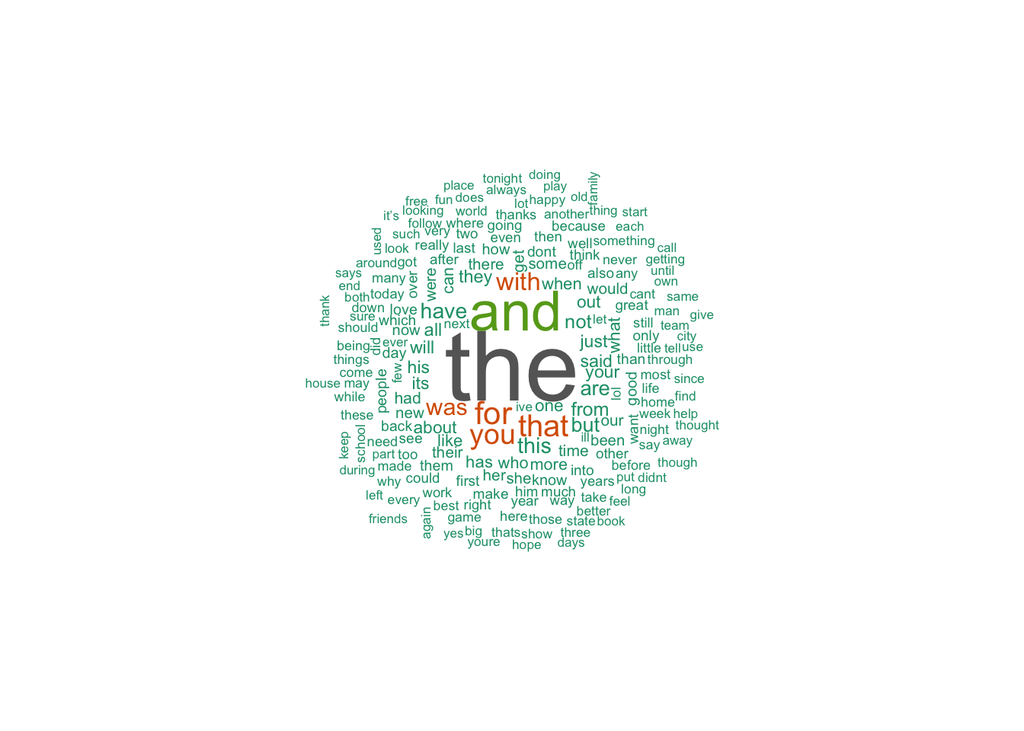

We can find from the graph that most used word in the sample is ‘the’, and this also represents the features of the raw data.

## Visualization of each Ngram levels for the sample files which represent the whole raw matrials , by tokenizing process.

### The plot for 40 most frequent Unigrams

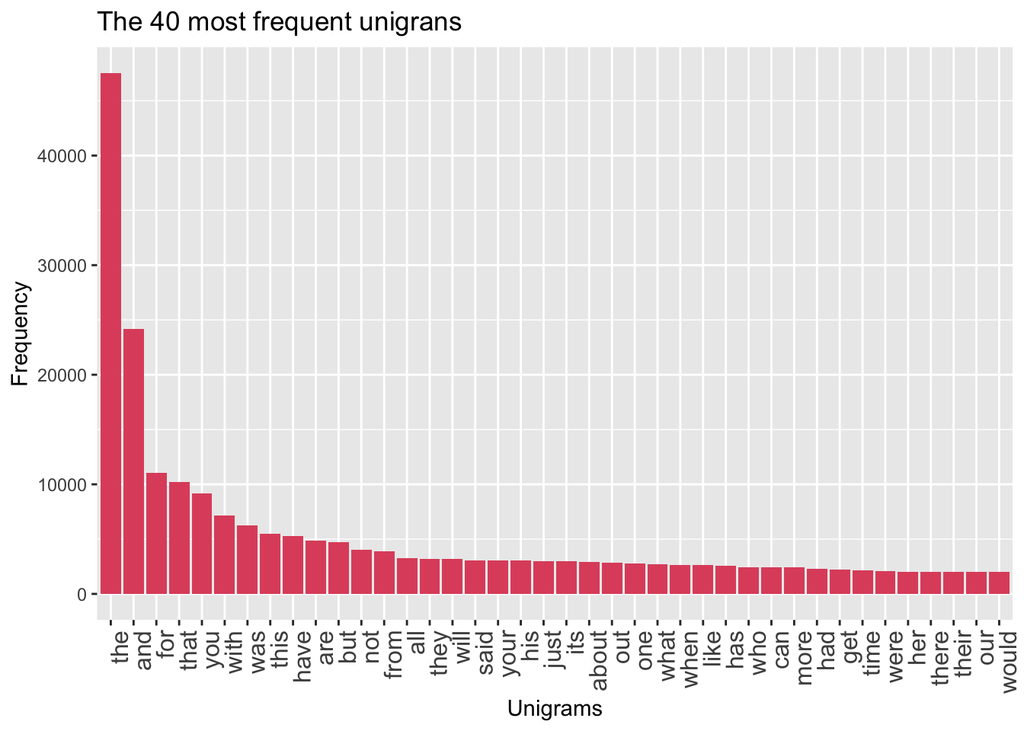

### The plot for 40 most frequent Bigrams

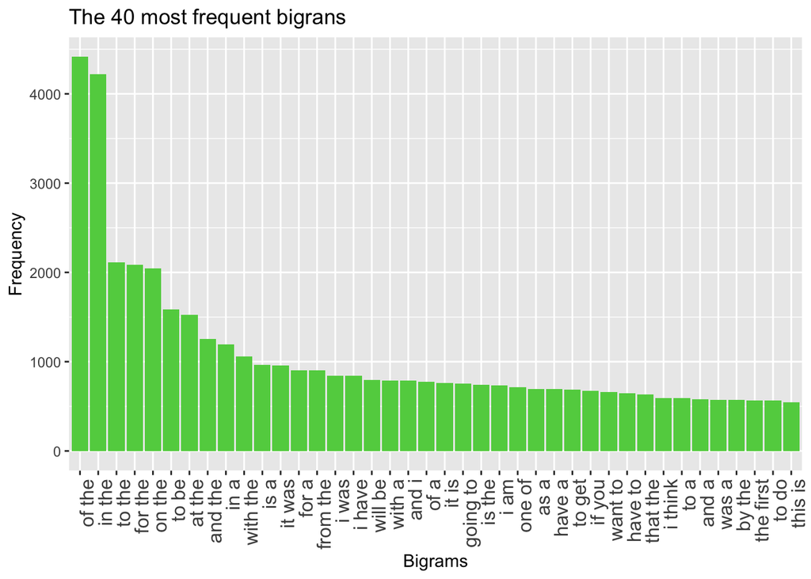

### The plot for 40 most frequent Trigrams

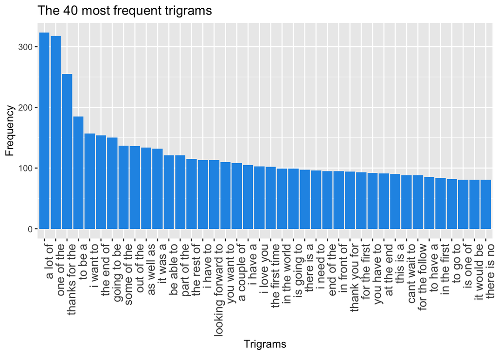

### Related conclusions

About 1% data of each original files was selected for the exploratory analysis. This may not be a large enough sample size.But, a data set that is too large can impede the efficiency of the analysis by placing a burden on the application used for analysis. It is important to find a good balance between sample size and analysis speed/efficiency.

## The Goals for Creating the Prediction Algorithm and Shiny

By now, the idea is to use the n-gram to predict next word. But from the app user perspective, the idea is to provide an input field in shiny app that returns the most probable word. The purpose of my completion of this course is to learn the skills that are necessary to develop the products of data analysis and to promote to the people who need them but lack the necessary skills.